# Exploring the NOAA Storm Database

Matti Salimi

Sunday, April 26, 2015

## Synopsis

This report aims to describe which storm-related event type has the biggest impact in harm toward human population and the largest economic consequences in the US. In terms of human life and injuries **tornado** has the biggest impact. When it comes to economic damage, it is again **tornado**.

## Data Processing

Data is downloaded and loaded into R. The full set contains 902297 observations with 37 variables, but not all are needed for the purpose of this analysis.

1. To perform the analysis the following variables are filtered: EVTYPE, FATALITIES, INJURIES, PROPDMG, PROPDMGEXP, CROPDMG and CROPDMGEXP.
2. Further filtering is performed by subsetting observations where FATALITIES, INJURIES, PROPDMG and CROPDMG is more than 0, and `EVTYPE=="?"` records are removed.
3. EVTYPE, PROPDMGEXP and CROPDMGEXP are converted to upper case.
4. Characters in PROPDMGEXP and CROPDMGEXP are mapped as follows:
- B = 100,000,000
- M = 1,000,000
- K = 1,000
- H = 100
- 2 to 7 = 10 to 1,000,000, corresponding to the number of digits
- all others = 1 PROPDMGEXP and CROPDMGEXP are then converted to numeric class so thatPROPDMG and CROPDMG can be multiplied to get the actual value.
5. Finally, for each type of weather event the sums of human harm and economic damage is aggregated

EVTYPES have been used raw as-is. It is beyond the scope of this analysis, which is to showcase reproducibility, to clean up and reduce this variable to be consistent with the 48 types which as described in the National Weather Service Instruction document.

```r
fileurl <- "https://d396qusza40orc.cloudfront.net/repdata%2Fdata%2FStormData.csv.bz2"
bz2file <- "repdata-data-StormData.csv.bz2"
if(!file.exists(bz2file)) {download.file(fileurl, bz2file)}

# Step 1
data <- read.csv(bzfile(bz2file), stringsAsFactors=FALSE)[,-c(1:7,9:22,29:37)]

# Step 2
data <- subset(data, FATALITIES > 0 | INJURIES > 0 | PROPDMG > 0 | CROPDMG > 0)
data <- subset(data, !EVTYPE=="?")

# Step 3
data$EVTYPE <- toupper(data$EVTYPE); data$PROPDMGEXP <- toupper(data$PROPDMGEXP)
data$CROPDMGEXP <- toupper(data$CROPDMGEXP)

# Step 4
data$PROPDMGEXP <- sapply(data$PROPDMGEXP, function(x)
    { if(x=="B") x<-"100000000"
        else if(x=="M"|x=="7") x<-"1000000"
            else if(x=="6") x<-"100000"
                else if(x=="5") x<-"10000"
                    else if(x=="K"|x=="4") x<-"1000"
                        else if(x=="H"|x=="3") x<-"100"
                            else if(x=="2") x<-"10"
      else x<-"1"})
data$CROPDMGEXP <- sapply(data$CROPDMGEXP, function(x)
    { if(x=="B") x<-"100000000"
        else if(x=="M"|x=="7") x<-"1000000"
            else if(x=="6") x<-"100000"
                else if(x=="5") x<-"10000"
                    else if(x=="K"|x=="4") x<-"1000"
                        else if(x=="H"|x=="3") x<-"100"
                            else if(x=="2") x<-"10"
      else x<-"1"})

data$PROPDMGEXP <- as.numeric(data$PROPDMGEXP)
data$PROPDMG <- data$PROPDMG * data$PROPDMGEXP
data$CROPDMGEXP <- as.numeric(data$CROPDMGEXP)
data$CROPDMG <- data$CROPDMG * data$CROPDMGEXP

# Step 5
aggr <- aggregate(.~EVTYPE, data, sum)
```

## Results

The storm-related type of event that is most harmful toward human populations in the US is **tornado**, followed by a far second in **excessive heat**. Below are top 10 lists of event types most harmful toward humans, for fatalities and injuries respectively.

```r
f <- aggr[order(aggr$FATALITIES, decreasing=TRUE),]
i <- aggr[order(aggr$INJURIES, decreasing=TRUE),]
head(f, 10)[,1:3]
```

```
##             EVTYPE FATALITIES INJURIES
## 370        TORNADO       5633    91346
## 53  EXCESSIVE HEAT       1903     6525
## 64     FLASH FLOOD        978     1777
## 132           HEAT        937     2100
## 232      LIGHTNING        816     5230
## 385      TSTM WIND        504     6957
## 77           FLOOD        470     6789
## 275    RIP CURRENT        368      232
## 178      HIGH WIND        248     1137
## 10       AVALANCHE        224      170
```

```r
head(i, 10)[,1:3]
```

```
##                EVTYPE FATALITIES INJURIES
## 370           TORNADO       5633    91346
## 385         TSTM WIND        504     6957
## 77              FLOOD        470     6789
## 53     EXCESSIVE HEAT       1903     6525
## 232         LIGHTNING        816     5230
## 132              HEAT        937     2100
## 215         ICE STORM         89     1975
## 64        FLASH FLOOD        978     1777
## 328 THUNDERSTORM WIND        133     1488
## 115              HAIL         15     1361
```

The costs of damage to properties and crops are both combined to measure total loss, in a summation. The graph below displays the top 10 storm events with greatest economical consequences. **Tornado** is again the most devastating storm-related event to economy, followed by **flood**.

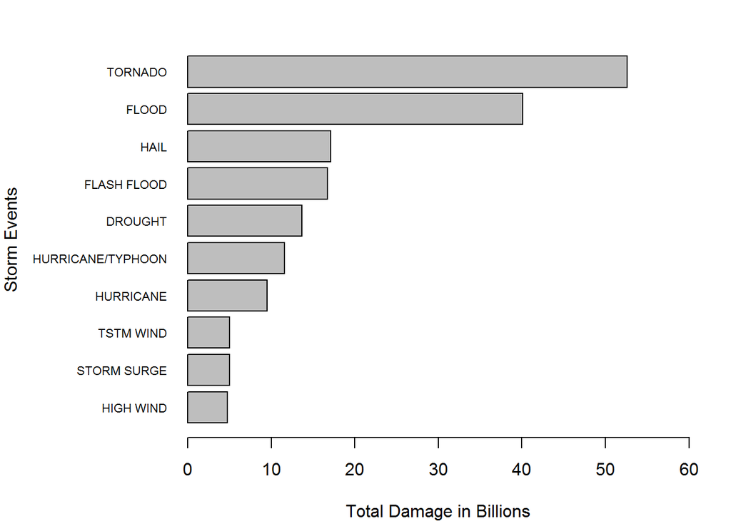

```r
aggr[,"TOTALDMG"] <- aggr[,"PROPDMG"] + aggr[,"CROPDMG"]
aggr <- aggr[order(aggr$TOTALDMG, decreasing=TRUE),]
par(mar=c(4,9,2,2))
barplot(aggr[10:1,"TOTALDMG"]/1000000000, names.arg=aggr[10:1,"EVTYPE"],
        ylab="", xlab="Total Damage in Billions", horiz=T, cex.names=0.7,
        las=1, xlim=c(0,60))
title(ylab="Storm Events", line=8)
```